[figure not shown]

# Entendiendo Jupyter Lab, Github, Python y Regresión Lineal

## Mineria de datos 2021-1

## Miguel Angel Robayo Bernal

## 1. introduccion

Regresión lineal. Permite determinar el grado de dependencia de las series de valores X y Y, prediciendo el valor y estimado que se obtendría para un valor x que no esté en la distribución.

# Tipos de modelos de regresión lineal

Existen diferentes tipos de regresión lineal que se clasifican de acuerdo a sus parámetros:

### Regresión lineal simple

La regresión lineal simple se basa en estudiar los cambios en una variable, no aleatoria, afectan a una variable aleatoria, en el caso de existir una relación funcional entre ambas variables que puede ser establecida por una expresión lineal, es decir, su representación gráfica es una línea recta. Es decir, se esta en presencia de una regresión lineal simple cuando una variable independiente ejerce influencia sobre otra variable dependiente.

Ejemplo: Y = f(x)

### Regresión lineal múltiple

La regresión lineal permite trabajar con una variable a nivel de intervalo o razón, así también se puede comprender la relación de dos o más variables y permitirá relacionar mediante ecuaciones, una variable en relación a otras variables llamándose Regresión múltiple. O sea, la regresión lineal múltiple es cuando dos o más variables independientes influyen sobre una variable dependiente.

Ejemplo: Y = f(x, w, z).

# Aplicaciones de la regresión lineal

### Líneas de tendencia

Una línea de tendencia representa una tendencia en una serie de datos obtenidos a través de un largo período. Este tipo de líneas puede decir si un conjunto de datos en particular (como por ejemplo, el PBI, el precio del petróleo o el valor de las acciones) han aumentado o decrementado en un determinado período. Las líneas de tendencia son generalmente líneas rectas, aunque algunas variaciones utilizan polinomios de mayor grado dependiendo de la curvatura deseada en la línea.

### Medicina

En Medicina, las primeras evidencias relacionando la mortalidad con el fumar tabaco vinieron de estudios que utilizaban la regresión lineal. Los investigadores incluyen una gran cantidad de variables en su análisis de regresión en un esfuerzo por eliminar factores que pudieran producir correlaciones espurias.

En el caso del Tabaquismo, los investigadores incluyeron el estado socio-económico para asegurarse que los efectos de mortalidad por tabaquismo no sean un efecto de su educación o posición económica. No obstante, es imposible incluir todas las variables posibles en un estudio de regresión.

En el ejemplo del tabaquismo, un hipotético gen podría aumentar la Mortalidad y aumentar la propensión a adquirir enfermedades relacionadas con el consumo de tabaco.

### Industria

En la industria tiene aplicación para investigar la relación entre el rendimiento de la producción y uno o más factores del (o de los) que depende, como la Temperatura, la humedad ambiental, la presión, la cantidad de insumos, etc; con base en este análisis se puede pronosticar el comportamiento de una variable que se desea estimar.

## 2.Historia

La primera forma de regresión lineal documentada ha sido el procedimiento de los mínimos cuadrados que ha sido publicada por Legendre en 1805, Gauss divulgó un trabajo en donde desarrollaba de forma más fuerte el procedimiento de los mínimos cuadrados, y en dónde se integraba una versión del teorema de Gauss-Márkov.

El concepto regresión se usó por primera ocasión en el análisis de cambiantes antropométricas: al equiparar la estatura de papás e hijos, donde terminó que los hijos cuyos papás tenían una estatura bastante preeminente al costo medio, tendían a igualarse a este, en lo que esos cuyos papás eran bastante bajos tendían a minimizar su diferencia en relación a la estatura media; o sea, "regresaban" al promedio. La constatación experimental de esta propiedad se observó reforzada después con la justificación teórica de aquel fenómeno.

El concepto lineal se emplea para distinguirlo del resto de técnicas de regresión, que emplean modelos basados en cualquier clase de funcionalidad matemática. Los modelos lineales son una descripción simplificada de la verdad, muchísimo más ágiles y con un soporte teórico muchísimo más largo de parte de la matemática y la estadística.

## 3.Algoritmo

Los algoritmos de Regresión modelan la relación entre distintas variables (features) utilizando una medida de error que se intentará minimizar en un proceso iterativo para poder realizar predicciones “lo más acertadas posible”. Se utilizan mucho en el análisis estadístico. El ejemplo clásico es la predicción de precios de Inmuebles a partir de sus características: cantidad de ambientes del piso, barrio, distancia al centro, metros cuadrados del piso, etc. Los Algoritmos más usados de Regresión son:

- Regresión Lineal
- Regresión Logística

# 4. Ejemplo de regresión lineal

Realizaremos un ejemplo sencillo, utilizando unos datos adquiridos desde la bolsa de valores de Colombia. https://www.bvc.com.co/pps/tibco/portalbvc/Home/Mercados/enlinea/indicesbursatiles?com.tibco.ps.pagesvc.renderParams.sub45d083c1_14321f5c9c5_-78350a0a600b=action%3Ddefecto%26org.springframework.web.portlet.mvc.ImplicitModel%3Dtrue%26

Lo primero sería importar los pandas, numpy y matplotlib, y luego veremos la tabla y grafica.

```python
# importar pandas
import pandas as pd
```

```python
# importemos numpy para manejo de arreglos
import numpy as np
```

```python
# importar matplotlib
import matplotlib.pyplot as plt
```

```python
path = "ind.xls"
```

```python
pd.read_excel(path)
```

|  | Indice | Mercado | Valor Hoy | Valor Ayer | VariaciÃ³n Absoluta | Variacion % | parte entera del valor hoy |
| --- | --- | --- | --- | --- | --- | --- | --- |
| 0 | COLCAP | RENTA VARIABLE | 1174.310000 | 1174.310000 | 0.000000 | 0.000000 | 1174 |
| 1 | COLEQTY | RENTA VARIABLE | 822.620000 | 822.620000 | 0.000000 | 0.000000 | 822 |
| 2 | COLIR | RENTA VARIABLE | 770.350000 | 770.350000 | 0.000000 | 0.000000 | 770 |
| 3 | COLSC | RENTA VARIABLE | 891.540000 | 891.540000 | 0.000000 | 0.000000 | 891 |
| 4 | COLTES | RENTA FIJA | 266.390000 | 267.420000 | -1.030000 | -0.390000 | 266 |
| 5 | COLTES CP | RENTA FIJA | 246.190000 | 245.890000 | 0.300000 | 0.120000 | 246 |
| 6 | COLTES LP | RENTA FIJA | 290.330000 | 292.230000 | -1.900000 | -0.650000 | 290 |
| 7 | COLTES UVR | RENTA FIJA | 290.350000 | 292.710000 | -2.360000 | -0.810000 | 290 |
| 8 | COLIBR | MERCADO MONETARIO | 183.117802 | 183.096924 | 0.020878 | 0.000114 | 183 |

```python
# datos
cap = ['COLCAP', 1174]
eqty = ['COLEQTY', 822]
ir = ['COLIR', 770]
sc = ['COLSC', 891]
tes = ['COLTES', 266]
tescp = ['COLTES CP', 246]
teslp = ['COLTES LP', 290]
tesuvr = ['COLTES UVR', 290]
ibr = ['COLIBR', 183]

# lista con datos
lista_ind = [cap, eqty, ir, sc, tes, tescp, teslp, tesuvr, ibr]

# crear dataframe a partir de listas
miniind=pd.DataFrame(lista_ind,
            columns = ['Indice', 'Valor hoy'])
miniind
```

|  | Indice | Valor hoy |
| --- | --- | --- |
| 0 | COLCAP | 1174 |
| 1 | COLEQTY | 822 |
| 2 | COLIR | 770 |
| 3 | COLSC | 891 |
| 4 | COLTES | 266 |
| 5 | COLTES CP | 246 |
| 6 | COLTES LP | 290 |
| 7 | COLTES UVR | 290 |
| 8 | COLIBR | 183 |

```python
miniind.head()
```

|  | Indice | Valor hoy |
| --- | --- | --- |
| 0 | COLCAP | 1174 |
| 1 | COLEQTY | 822 |
| 2 | COLIR | 770 |
| 3 | COLSC | 891 |
| 4 | COLTES | 266 |

```python
miniind.shape
```

```
(9, 2)
```

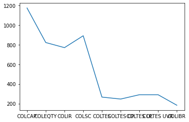

```python
plt.plot(miniind['Indice'], miniind['Valor hoy'])
plt.show()
```

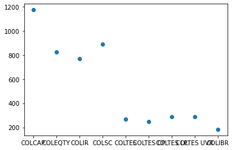

```python
plt.scatter(miniind['Indice'], miniind['Valor hoy'])
plt.show()
```

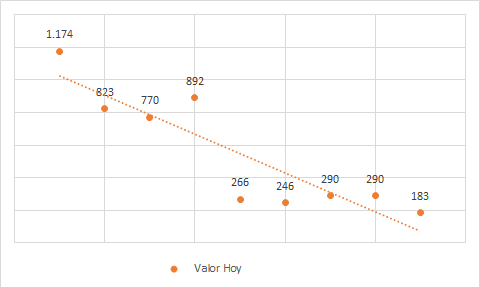

## 5.Conclusiones

- La regresión lineal cumple un papel fundamental en la estadística, al ser un modelo matemático usado para aproximar la relación de dependencia entre dos variables
- Python es un lenguaje de programación moderno, y su desarrollo es muy importante a la hora de hablar de ciencia de datos
- Jupyter es una herramienta vital en la implementación de Machine learning, ya que permite mesclar lo mejor de varios mundos

## Fuentes

- Artículo Regresión lineal. Disponible en la Web "sc.ehu.es". Consultado: 12 de marzo del 2021.
- Artículo Aula fácil. Disponible en la Web "aulafacil.com". Consultado: 12 de marzo del 2021.
- Aprende Machine learning. Disponible en la web "https://www.aprendemachinelearning.com//" Consultado: 12 de marzo del 2021.
- Programacion para Data Science. Disponible en la web "https://gonzalezgouveia.com/" Consultado: 12 de marzo del 2021.